# Data Analysis Final

Shubham Agrawal

2026-03-04

# 1 Load the MultiAssayExperiment objects

Load the MultiAssayExperiment object of the InSolutionDigest experiment:

Load the MultiAssayExperiment object of the TitrationCurve experiment:

Get only the T2 samples

# 2 Get the SummarizedExperiment object of phosphoproteome assay

Extract the phosphoproteome experiments from both the objects.

# 3 Load the combined mae object

```r
mae <- readRDS("data/maeCombined_20260223.Rds")
maeSmartPhos <- mae[, mae$experiment == "SmartPhos"]
maeInSol <- mae[, mae$experiment == "InSolution"]

seTitration <- maeSmartPhos[["Phosphoproteome"]]
colData(seTitration) <- colData(maeSmartPhos)

seInSolution <- maeInSol[["Phosphoproteome"]]
colData(seInSolution) <- colData(maeInSol)
```

# 4 Plot the total phosphosites detected

```r
seTitrationHGFCtrl <- seTitration[, seTitration$sampleType == "PP"]
# Extract the assay data from the SummarizedExperiment object
countMat1 <- assay(seTitrationHGFCtrl)

# Extract intensity matrix and protein names
protein_names1 <- rowData(seTitrationHGFCtrl)$UniprotID

# Count unique proteins with non-NA intensities per sample
protein_counts1 <- sapply(seq_len(ncol(countMat1)), function(i) {
  detected <- !is.na(countMat1[, i]) & !is.na(protein_names1)
  length(unique(protein_names1[detected]))
})

# Create a table with sample names and their corresponding percentage of
# non-missing values
plotTab1 <- tibble(
  sample = seTitrationHGFCtrl$sample,
  totalProteins = protein_counts1,
  totalPhosphosites = colSums(!is.na(countMat1))
)

# Extract metadata from the SummarizedExperiment object
meta1 <- as.data.frame(colData(seTitrationHGFCtrl))
# Join the count data with metadata
plotTab1 <- left_join(plotTab1, meta1, by = "sample")

plotTab1 <- plotTab1 %>%
  mutate(quantity = factor(quantity,
                           levels = c("5ug","15ug","50ug","200ug","750ug"),
                           ordered = TRUE)) %>%
  arrange(quantity) %>%
  mutate(sample = factor(sample, levels = sample))
```

```
## Ignoring unknown labels:
## • colour : "Treatment"
```

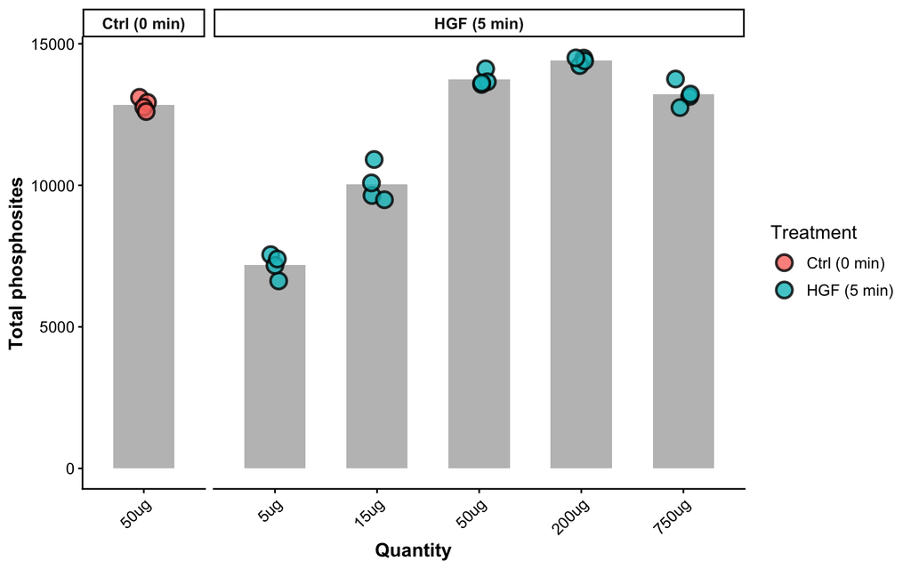

```r
# Prepare data
plotTab_filtered <- plotTab1 %>%
  mutate(
    treatment = trimws(as.character(treatment)),
    quantity = trimws(as.character(quantity))
  ) %>%
  filter(
    (treatment == "unstimulated" & quantity == "50ug") |
    (treatment == "HGF" &
       quantity %in% c("5ug", "15ug", "50ug", "200ug", "750ug"))
  ) %>%
  mutate(
    quantity = factor(
      quantity,
      levels = c("5ug", "15ug", "50ug", "200ug", "750ug")
    ),
    treatment = factor(
      treatment,
      levels = c("unstimulated", "HGF")
    )
  )

# Calculate means
plot_average <- plotTab_filtered %>%
  group_by(treatment, quantity) %>%
  summarise(
    meanPhosphosites = mean(totalPhosphosites, na.rm = TRUE),
    .groups = "drop"
  )

# Plot
ggplot(plotTab_filtered,
       aes(x = quantity, y = totalPhosphosites)) +

  # Average bars
  geom_col(
    data = plot_average,
    aes(y = meanPhosphosites),
    fill = "grey75",
    width = 0.6
  ) +

  # Individual replicates
  geom_point(
    aes(fill = treatment),
    shape = 21,
    color = "black",
    stroke = 1.2,
    position = position_jitter(width = 0.08, height = 0),
    size = 4,
    alpha = 0.80
  ) +

  # Separate treatment facets
  facet_grid(. ~ treatment, scales = "free_x", space = "free_x",
             labeller = labeller(
               treatment = c("unstimulated" = "Ctrl (0 min)",
                             "HGF" = "HGF (5 min)"))
  ) +
  scale_fill_discrete(
  name = "Treatment",
  labels = c(
    "unstimulated" = "Ctrl (0 min)",
    "HGF" = "HGF (5 min)"
  )) +
  labs(
    x = "Quantity",
    y = "Total phosphosites",
    color = "Treatment"
  ) +

  theme_classic() +

  theme(
    strip.background = element_rect(fill = "white"),
    strip.text = element_text(face = "bold", size = 10),
    axis.title.x = element_text(size = 12, face = "bold"),
    axis.title.y = element_text(size = 12, face = "bold"),
    axis.text.x = element_text(angle = 45, hjust = 1),
    axis.title = element_text(face = "bold"),
    axis.text = element_text(color = "#000000", size = 10),
    legend.title = element_text(size = 12),
    legend.text = element_text(size = 10)
  )
```

```r
seInSolutionHGF <- seInSolution[, seInSolution$treatment == "HGF" &
                                  seInSolution$sampleType == "PP"]
seTitrationHGF <- seTitration[, seTitration$treatment == "HGF" &
                                  seTitration$sampleType == "PP"]
```

This plot shows the total number of phosphosites detected for each sample in the SmartPhos experiment. Here each bar is coloured by the quantity value. We see 50ug, 200ug and 750ug samples have similar number of phosphosites detected. Increasing the sample quantity to 750ug doesn’t improve the phophosite detection.

```r
# Extract the assay data from the SummarizedExperiment object
countMat <- assay(seTitrationHGF)

# Extract intensity matrix and protein names
protein_names <- rowData(seTitrationHGF)$UniprotID

# Count unique proteins with non-NA intensities per sample
protein_counts <- sapply(seq_len(ncol(countMat)), function(i) {
  detected <- !is.na(countMat[, i]) & !is.na(protein_names)
  length(unique(protein_names[detected]))
})

# Create a table with sample names and their corresponding percentage of
# non-missing values
plotTab <- tibble(
  sample = seTitrationHGF$sample,
  totalProteins = protein_counts,
  totalPhosphosites = colSums(!is.na(countMat))
)

# Extract metadata from the SummarizedExperiment object
meta <- as.data.frame(colData(seTitrationHGF))
# Join the count data with metadata
plotTab <- left_join(plotTab, meta, by = "sample")

plotTab <- plotTab %>%
  mutate(quantity = factor(quantity,
                           levels = c("5ug","15ug","50ug","200ug","750ug"),
                           ordered = TRUE)) %>%
  arrange(quantity) %>%
  mutate(sample = factor(sample, levels = sample))
```

```r
# Proteins detected in every sample
common_proteins <- unique(
  protein_names[
    !is.na(protein_names) &
    rowSums(!is.na(countMat)) > 0
  ]
)

# Keep only proteins detected in all samples
common_proteins <- unique(
  protein_names[
    !is.na(protein_names) &
    rowSums(!is.na(countMat)) == ncol(countMat)
  ]
)

# Number of common proteins
length(common_proteins)
```

```
## [1] 1801
```

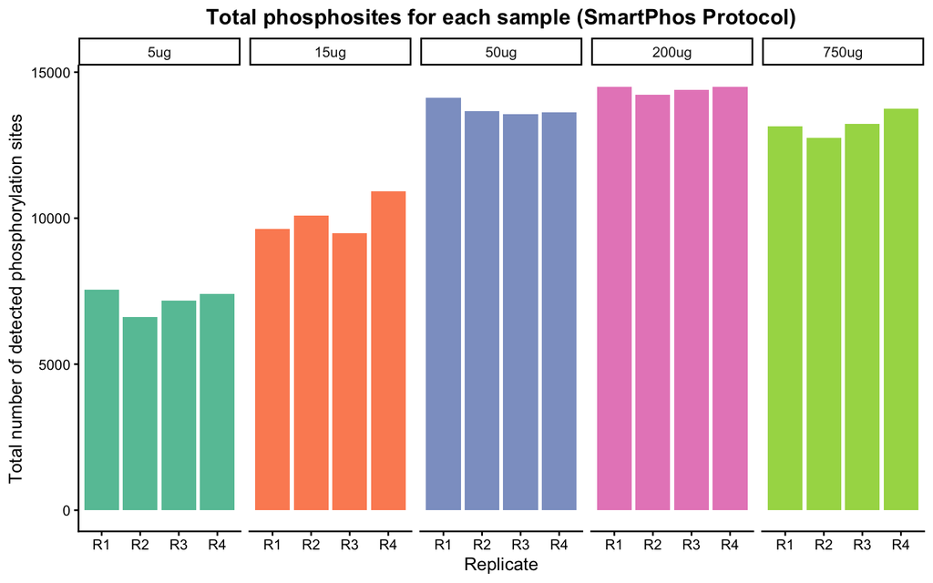

```r
# Generate the bar plot using ggplot2
g <- ggplot(plotTab, aes(x = replicate, y = totalPhosphosites , fill = quantity)) +
  geom_bar(stat = "identity") +
  scale_fill_brewer(palette = "Set2") +
  ggtitle("Total phosphosites for each sample (SmartPhos Protocol)") +
  ylab("Total Phosphosites") +
  theme_classic() +
  theme(legend.position = "none",
    plot.title = element_text(hjust = 0.5, face = "bold")
  ) + ylab("Total number of detected phosphorylation sites") + xlab("Replicate") +
  facet_grid(~ quantity, scales="free")

g
```

This plot compares the total phosphosites detected in both experiments for 50ug samples. The plot shows that the SmartPhos experiment detects more phosphosites as compared to the InSolutionDigest experiment.

```r
seD <- seInSolution[, seInSolution$treatment == "HGF"
                    & seInSolution$quantity == "50ug"]
countMatD <- assay(seD)
# Extract intensity matrix and protein names
proteinD <- rowData(seD)$UniprotID
# Count unique proteins with non-NA intensities per sample
protein_countsD <- sapply(seq_len(ncol(countMatD)), function(i) {
  detected <- !is.na(countMatD[, i]) & !is.na(proteinD)
  length(unique(proteinD[detected]))
})
plotTabD <- tibble(
  sample = seD$sample,
  replicate = seD$replicate,
  totalProteins = protein_countsD,
  totalPhosphosites = colSums(!is.na(countMatD)),
  experiment = "InSolutionDigest"
)


seT <- seTitration[, seTitration$treatment == "HGF"
                    & seTitration$quantity == "50ug"]
countMatT <- assay(seT)
# Extract intensity matrix and protein names
proteinT <- rowData(seT)$UniprotID
# Count unique proteins with non-NA intensities per sample
protein_countsT <- sapply(seq_len(ncol(countMatT)), function(i) {
  detected <- !is.na(countMatT[, i]) & !is.na(proteinT)
  length(unique(proteinT[detected]))
})
plotTabT <- tibble(
  sample = seT$sample,
  replicate = seT$replicate,
  totalProteins = protein_countsT,
  totalPhosphosites = colSums(!is.na(countMatT)),
  experiment = "SmartPhos"
)

plotTabComb <- rbind(plotTabD, plotTabT)
```

```r
write.csv(plotTabComb, "totalComparisonInSolutionTitration.csv", row.names = FALSE)
```

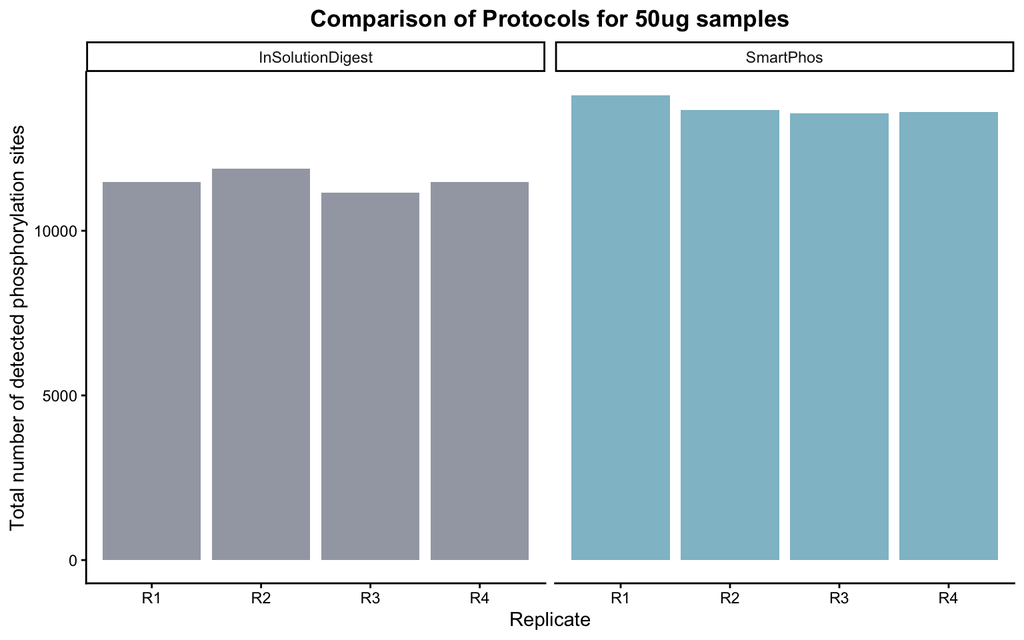

```r
# Generate the bar plot using ggplot2
g <- ggplot(plotTabComb, aes(x = replicate, y = totalPhosphosites)) +
  geom_bar(stat = "identity" , aes(fill = experiment)) +
  ggtitle("Comparison of Protocols for 50ug samples") +
  ylab("Total number of detected phosphorylation sites") + xlab("Replicate") +
  scale_fill_manual(values = c("InSolutionDigest" = "#a3a7b2",
                               "SmartPhos" = "#90bfce")) +
  theme_classic() +
  theme(legend.position = "none",
    plot.title = element_text(hjust = 0.5, face = "bold")
  ) +
  facet_grid(~ experiment, scales="free")

g
```